# Python BootCamp Day 2: Python for Finance

Wanyi Wang (University of California Irvine, 2020 fall)

12/7/2020

**What did we learn last week?**

- Variable and data types: string, number, boolean
- Control flow: if, loop
- Data structure: list, dictionary

**What will we learn this week?**

- Access financial data from public resources in Python: Yahoo! Finance, Federal reserve, world bank, etc.
- Calculate financial statistics with Python: expected return, variance, covariance, etc.
- Make cool plots to visualize your data.

**Mini Project🎈**

Suppose you are want to apply for an investment manager position at a large mutual fund. You are asked to present a thorough analysis on a set of public stocks. You need to:

- Download historical stock prices and analyze their past performance.
- Pick the stock with the larest sharpe ratio.
- Construct portfolio from given stocks.
- Optimize your portfolio: allocate your money among these stocks to maximize risk-return tradeoff and plot the minimum variance frontier.

I split the project into 4 tasks, and we will tackle them one by one during our class today.

## 1. Access financial data

Nowadays, millions of data are generated, transmitted and stored on Internet every day. Many financial institutions, government departments and tech companies offer public access to large amount of well-organized data. These data can be accessed through application programming interface (API), an interface that allow Python (and other programming languages) to download data directly **within** your code.

We will learn a cool package: **pandas-datareader**. Before that, let me introduce Python "package" to you.

### 1.1 Package in Python

**What is package? Why do we need packages?**

- A python package is collection of functions that perform certain tasks.
- They are ready-to-use tools so you don’t need to build everything from the very beginning.
- For example:
  - Programming: build a house
  - Function: hammer, screwdriver, nail, etc.
  - Package: a toolbox

#### 1.1.1 Download and install package

Anaconda already pre-installed many common packages. However, if you want to use a package that is not on your computer yet, you need to download and install it manually. We can use the following command to install a package:

**pip install `package_name`**

Note that this is **NOT** a Python command, but Jupyter Notebook has a "magic" feature: if you put an exclamation mark before the command, you can execude the code within Jupyter Notebook.

```python
# magic command
!pip install pandas-datareader
```

**Note**: You only need to install the package **ONCE**. You don't need to run the code every time you want to use the package.

#### 1.1.2 Import package

To use Python packages, you need to import it into your code. Just like you need to take the hammer out of the toolbox if you want to use it.

There are several ways to import a package:

- **import `package_name`**: import the whole package.
- **import `package_name` as `abbr.`**: import the whole package and refer to it as an abbreviation.
- **from `package_name` import `function_name`**: only import a specific function from the package.

```python
# Example
import pandas_datareader
import pandas_datareader as pdr
from pandas_datareader import get_data_yahoo
```

**Note:**: You need to import the package **EVERY TIME** you execute the code.

### 1.2 Access data from Pandas-datareader

Pandas datareader is a **remote data access package** that allows one to get data from various internet data sources.

You can access data from:

- **Yahoo! finance**: stock price, trading volume
- **Nasdaq Trader symbol**: a list of all available equity symbols from Nasdaq.
- **St.Louis FED (FRED)**: Federal Reserve's economic data
- **Kenneth French’s data library**: Fama-French factors, risk free rate, etc.
- **World Bank**: gdp, international debt, human capital, etc.

Other data sources supported:

- Tiingo, IEX, Alpha Vantage, Enigma, Quandl, Eurostat, Thrift Savings Plan, Stooq, MOEX

Each data source is accessed using different functions or parameters, because each API requires different information to be privided. Documentation on how to access each data source with pandas-datareader can be found [here](https://pandas-datareader.readthedocs.io/en/latest/remote_data.html).

```python
amazon_price = pdr.get_data_yahoo('AMZN')
```

```python
amazon_price.head()
```

| Date | High | Low | Open | Close | Volume | Adj Close |
| --- | --- | --- | --- | --- | --- | --- |
| 2015-12-10 | 668.530029 | 659.559998 | 665.590027 | 662.320007 | 3455500 | 662.320007 |
| 2015-12-11 | 657.880005 | 639.619995 | 651.229980 | 640.150024 | 5474400 | 640.150024 |
| 2015-12-14 | 658.590027 | 635.270020 | 641.750000 | 657.909973 | 4329700 | 657.909973 |
| 2015-12-15 | 671.500000 | 657.349976 | 665.030029 | 658.640015 | 4753400 | 658.640015 |
| 2015-12-16 | 677.349976 | 659.320007 | 663.559998 | 675.770020 | 3964500 | 675.770020 |

```python
# You can specify your preferred start and end date
amazon_price = pdr.get_data_yahoo('AMZN', start = '2010-1-1', end = '2019-11-30')
```

```python
amazon_price.head()
```

| Date | High | Low | Open | Close | Volume | Adj Close |
| --- | --- | --- | --- | --- | --- | --- |
| 2010-01-04 | 136.610001 | 133.139999 | 136.250000 | 133.899994 | 7599900 | 133.899994 |
| 2010-01-05 | 135.479996 | 131.809998 | 133.429993 | 134.690002 | 8851900 | 134.690002 |
| 2010-01-06 | 134.729996 | 131.649994 | 134.600006 | 132.250000 | 7178800 | 132.250000 |
| 2010-01-07 | 132.320007 | 128.800003 | 132.009995 | 130.000000 | 11030200 | 130.000000 |
| 2010-01-08 | 133.679993 | 129.029999 | 130.559998 | 133.520004 | 9830500 | 133.520004 |

```python
# You can also access multiple stocks together
amazon_google_microsoft_price = pdr.get_data_yahoo(['AMZN','GOOG','MSFT'])
```

```python
amazon_google_microsoft_price.head()
```

| Attributes Symbols Date | Adj Close AMZN | Adj Close GOOG | Adj Close MSFT | Close AMZN | Close GOOG | Close MSFT | High AMZN | High GOOG | High MSFT | Low AMZN | Low GOOG | Low MSFT | Open AMZN | Open GOOG | Open MSFT | Volume AMZN | Volume GOOG | Volume MSFT |
| --- | --- | --- | --- | --- | --- | --- | --- | --- | --- | --- | --- | --- | --- | --- | --- | --- | --- | --- |
| 2015-12-10 | 662.320007 | 749.460022 | 50.435631 | 662.320007 | 749.460022 | 55.270000 | 668.530029 | 755.849976 | 55.660000 | 659.559998 | 743.830017 | 55.009998 | 665.590027 | 752.849976 | 55.389999 | 3455500.0 | 1988400.0 | 31775800.0 |
| 2015-12-11 | 640.150024 | 738.869995 | 49.331478 | 640.150024 | 738.869995 | 54.060001 | 657.880005 | 745.710022 | 55.099998 | 639.619995 | 736.750000 | 54.009998 | 651.229980 | 741.159973 | 54.709999 | 5474400.0 | 2224400.0 | 39549500.0 |
| 2015-12-14 | 657.909973 | 747.770020 | 50.317013 | 657.909973 | 747.770020 | 55.139999 | 658.590027 | 748.729980 | 55.209999 | 635.270020 | 724.169983 | 53.680000 | 641.750000 | 741.789978 | 54.330002 | 4329700.0 | 2412500.0 | 46768900.0 |
| 2015-12-15 | 658.640015 | 743.400024 | 50.371754 | 658.640015 | 743.400024 | 55.200001 | 671.500000 | 758.080017 | 55.900002 | 657.349976 | 743.010010 | 55.090000 | 665.030029 | 753.000000 | 55.660000 | 4753400.0 | 2666200.0 | 39843000.0 |
| 2015-12-16 | 675.770020 | 758.090027 | 51.220406 | 675.770020 | 758.090027 | 56.130001 | 677.349976 | 760.590027 | 56.250000 | 659.320007 | 739.434998 | 54.759998 | 663.559998 | 750.000000 | 55.540001 | 3964500.0 | 1993300.0 | 37503300.0 |

**🤓 Exercise 1: Download the following five stocks' stock price from 2016 to 2020 from Yahoo Finance:**

- Apple (ticker: AAPL)
- Chevron (ticker: CVX)
- Starbucks (ticker: SBUX)
- Nike (ticker: NKE)
- Pfizer (ticker: PFE)

Can you tell me:

1. Which stock has the highest price among all stocks prior to 2020?
2. Which stock has the highest price since 2020?
3. Which stock is hit the strongest by the COVID-19 shock?

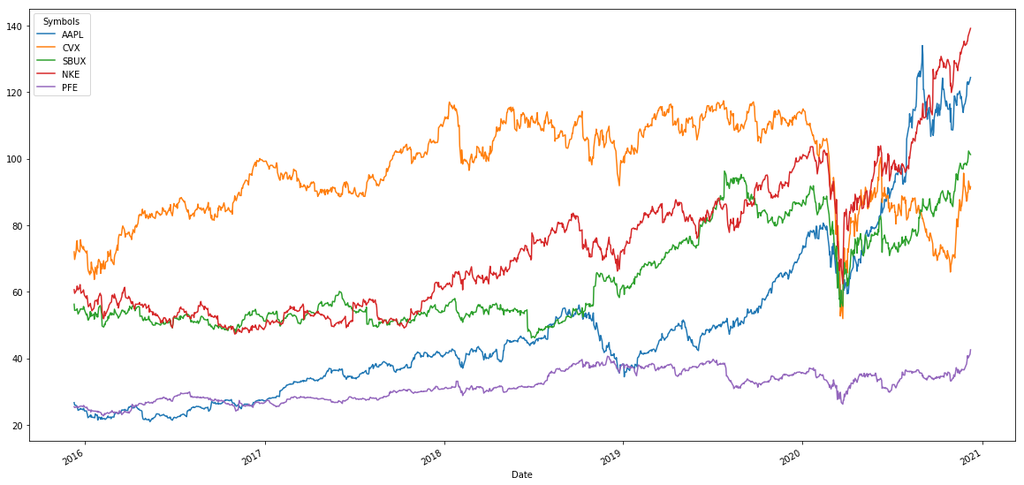

```python
# exercise 1
import pandas_datareader as pdr

# You can use function "get_data_yahoo" to access data from Yahoo! Finance.
# Please complete the code below to get the five stocks' stock prices from 2016-1-1 to 2020-12-04
# and save the result to a variable named "stock_prices"

# ___________ = ___.__________(_______,________,_______)

# Answer:
stock_prices = pdr.get_data_yahoo(['AAPL','CVX','SBUX','NKE', 'PFE'])


# The following code extract daily closing price and plot the trend over time.
# Don't worry if you don't understand now. I'll explain it in later sections.
closing_price = stock_prices['Adj Close']
closing_price.plot(figsize=(20,10))
```

## 2. Analyze financial data

After downloading your data, you can now perform many meaningful financial analyses. **`Pandas`** is the workhorse to conduct data analysis in Python. It organizes data in a way similar to Excel, but augmented all the power and flexibility of Python. In this section, you will learn how to:

- Create a table from scratch/a local file
- Select a subset of the table
- Modify the table to add more information
- Calculate financial statistics from the table

**Pandas stores data in "DataFrame". What is DataFrame?**

- A table-like data structure in Pandas.
- Similar to "spreadsheet" in Excel.
- DataFrame has rows and columns.
  - Each column has a name (e.g. "High", "Low", "Volume")
  - Each row has an index (e.g. "2015-12-07")

```python
# example
amazon_price.head()
```

| Date | High | Low | Open | Close | Volume | Adj Close |
| --- | --- | --- | --- | --- | --- | --- |
| 2010-01-04 | 136.610001 | 133.139999 | 136.250000 | 133.899994 | 7599900 | 133.899994 |
| 2010-01-05 | 135.479996 | 131.809998 | 133.429993 | 134.690002 | 8851900 | 134.690002 |
| 2010-01-06 | 134.729996 | 131.649994 | 134.600006 | 132.250000 | 7178800 | 132.250000 |
| 2010-01-07 | 132.320007 | 128.800003 | 132.009995 | 130.000000 | 11030200 | 130.000000 |
| 2010-01-08 | 133.679993 | 129.029999 | 130.559998 | 133.520004 | 9830500 | 133.520004 |

### 2.1 Creat a dataframe

```python
# first, import the package. People usually use "pd" as pandas' abbreviation.
import pandas as pd
```

#### 2.1.1 Create with dictionary

You can create a dataframe from a **dictionary**. In this way, you should specify values for each column.

```python
# use dictionary to define a dataframe
car_dictionary = {'Brand': ['Honda Civic','Toyota Corolla','Ford Focus','Audi A4'],
                  'Price': [22000, 25000, 27000, 35000],
                  'Dealer': ['Irvine','Tustin','Costa Mesa','Anaheim']}

car_df = pd.DataFrame(car_dictionary)
car_df
```

|  | Brand | Price | Dealer |
| --- | --- | --- | --- |
| 0 | Honda Civic | 22000 | Irvine |
| 1 | Toyota Corolla | 25000 | Tustin |
| 2 | Ford Focus | 27000 | Costa Mesa |
| 3 | Audi A4 | 35000 | Anaheim |

#### 2.1.2 Create with list

Alternatively, you can create a dataframe from a **list**. In this way, you should specify values for each row.

```python
# use list to define a dataframe
car_list = [['Honda Civic',22000,'Irvine'],
            ['Toyota Corolla',25000,'Tustin'],
            ['Ford Focus',27000,'Costa Mesa'],
            ['Audi A4',35000,'Anaheim']]

car_df = pd.DataFrame(car_list, columns=['Brand', 'Price', 'Dealer'])
car_df
```

|  | Brand | Price | Dealer |
| --- | --- | --- | --- |
| 0 | Honda Civic | 22000 | Irvine |
| 1 | Toyota Corolla | 25000 | Tustin |
| 2 | Ford Focus | 27000 | Costa Mesa |
| 3 | Audi A4 | 35000 | Anaheim |

#### 2.1.3 Import from local file

When datasets get larger, you cannot create it from scratch. Most often, you will import data from a local file.

- **Syntax**: `DataFrame_name` = pd.read_csv(`file_name`)
- Note that you should put the file under the same folder as this Jupyter notebook.
- Other I/O functions: read_excel(), read_html(), read_stata(), read_json()...

```python
apple_price = pd.read_csv('stock_price_apple.csv')
apple_price.head()
```

|  | Date | High | Low | Open | Close | Volume | Adj Close |
| --- | --- | --- | --- | --- | --- | --- | --- |
| 0 | 2010-01-04 | 30.642857 | 30.340000 | 30.490000 | 30.572857 | 123432400.0 | 26.601469 |
| 1 | 2010-01-05 | 30.798571 | 30.464285 | 30.657143 | 30.625713 | 150476200.0 | 26.647457 |
| 2 | 2010-01-06 | 30.747143 | 30.107143 | 30.625713 | 30.138571 | 138040000.0 | 26.223597 |
| 3 | 2010-01-07 | 30.285715 | 29.864286 | 30.250000 | 30.082857 | 119282800.0 | 26.175119 |
| 4 | 2010-01-08 | 30.285715 | 29.865715 | 30.042856 | 30.282858 | 111902700.0 | 26.349140 |

Similarly, you can output your data to a local file.

- **Syntax**: `DataFrame_name`.to_csv(`file_name`)
- Note that the data will be saved under the same folder as this Jupyter notebook.

```python
apple_price.to_csv('stock_price_apple_copy.csv')
```

### 2.2 View your data

There are several built-in functions to help you inspect your data:

- **head()**: display the first several rows
- **tail()**: display the last several rows
- **nlargest()**: display the largest several rows
- **nsmallest()**: display the smallest several rows

```python
# Syntax: variable_name.head(number_of_rows)
amazon_price.head(5)
```

| Date | High | Low | Open | Close | Volume | Adj Close |
| --- | --- | --- | --- | --- | --- | --- |
| 2010-01-04 | 136.610001 | 133.139999 | 136.250000 | 133.899994 | 7599900 | 133.899994 |
| 2010-01-05 | 135.479996 | 131.809998 | 133.429993 | 134.690002 | 8851900 | 134.690002 |
| 2010-01-06 | 134.729996 | 131.649994 | 134.600006 | 132.250000 | 7178800 | 132.250000 |
| 2010-01-07 | 132.320007 | 128.800003 | 132.009995 | 130.000000 | 11030200 | 130.000000 |
| 2010-01-08 | 133.679993 | 129.029999 | 130.559998 | 133.520004 | 9830500 | 133.520004 |

```python
amazon_price.tail(3) # display the last 3 rows
```

| Date | High | Low | Open | Close | Volume | Adj Close |
| --- | --- | --- | --- | --- | --- | --- |
| 2019-11-26 | 1797.030029 | 1778.349976 | 1779.920044 | 1796.939941 | 3181200 | 1796.939941 |
| 2019-11-27 | 1824.500000 | 1797.310059 | 1801.000000 | 1818.510010 | 3025600 | 1818.510010 |
| 2019-11-29 | 1824.689941 | 1800.790039 | 1817.780029 | 1800.800049 | 1923400 | 1800.800049 |

```python
# Syntax: variable_name.nlargest(number_of_rows, column_to_compare)
amazon_price.nlargest(5, 'Volume')    # 5 days with the most trading volume
```

| Date | High | Low | Open | Close | Volume | Adj Close |
| --- | --- | --- | --- | --- | --- | --- |
| 2010-07-23 | 119.279999 | 105.800003 | 105.930000 | 118.870003 | 42421100 | 118.870003 |
| 2010-02-01 | 124.860001 | 113.820000 | 123.180000 | 118.870003 | 37774400 | 118.870003 |
| 2010-01-29 | 131.850006 | 124.139999 | 129.770004 | 125.410004 | 29471300 | 125.410004 |
| 2010-01-28 | 127.199997 | 122.800003 | 124.430000 | 126.029999 | 27293100 | 126.029999 |
| 2011-10-26 | 207.580002 | 196.509995 | 203.690002 | 198.399994 | 24134200 | 198.399994 |

```python
amazon_price.nsmallest(5, 'Volume')
```

| Date | High | Low | Open | Close | Volume | Adj Close |
| --- | --- | --- | --- | --- | --- | --- |
| 2012-12-24 | 259.500000 | 256.959991 | 257.299988 | 258.619995 | 984400 | 258.619995 |
| 2015-12-24 | 664.679993 | 660.599976 | 663.349976 | 662.789978 | 1091200 | 662.789978 |
| 2012-07-03 | 229.529999 | 227.589996 | 229.139999 | 229.529999 | 1331700 | 229.529999 |
| 2015-07-02 | 438.200012 | 433.480011 | 437.000000 | 437.709991 | 1343400 | 437.709991 |
| 2013-09-13 | 300.220001 | 296.200012 | 300.140015 | 297.920013 | 1350600 | 297.920013 |

### 2.3 Select a subset of data

#### 2.3.1 Select by column

Often times, not all information in a dataset is useful to you. For example, you may only need the closing price of a stock.

**Syntax**: `variable_name` = DataFrame_name[`'column_name'`]

```python
# Select a single column
closing_price = amazon_price['Adj Close']
closing_price.head()
```

```
Date
2010-01-04    133.899994
2010-01-05    134.690002
2010-01-06    132.250000
2010-01-07    130.000000
2010-01-08    133.520004
Name: Adj Close, dtype: float64
```

**Note:** Adjusted close ("adj close") is the closing price after adjustments for all applicable stock splits and dividend distributions.

```python
# Select multiple columns
closing_price_and_volume = amazon_price[['Adj Close', 'Volume']]
closing_price_and_volume.head()
```

| Date | Adj Close | Volume |
| --- | --- | --- |
| 2010-01-04 | 133.899994 | 7599900 |
| 2010-01-05 | 134.690002 | 8851900 |
| 2010-01-06 | 132.250000 | 7178800 |
| 2010-01-07 | 130.000000 | 11030200 |
| 2010-01-08 | 133.520004 | 9830500 |

**Note:** We use **TWO** square brackets [[ ]] to select multiple columns. This is because we first put all column names in a list (['Adj Close', 'Volume']), and then use the list to select multiple columns from the data. I know this is counterintuitive, but it is how it works😂

#### 2.3.2 Select by row

You can also select a subset of dataset by rows. You can either select by location or by logic criteria.

**Syntax**: `DataFrame_name`.iloc[`start_row`:`end_row_plus_one`]

```python
# Select rows by index location (5th, 6th, ... 9th row)
amazon_price.iloc[5:10]
```

| Date | High | Low | Open | Close | Volume | Adj Close |
| --- | --- | --- | --- | --- | --- | --- |
| 2010-01-11 | 132.800003 | 129.210007 | 132.619995 | 130.309998 | 8779400 | 130.309998 |
| 2010-01-12 | 129.820007 | 126.550003 | 128.990005 | 127.349998 | 9096300 | 127.349998 |
| 2010-01-13 | 129.710007 | 125.750000 | 127.900002 | 129.110001 | 10723200 | 129.110001 |
| 2010-01-14 | 130.380005 | 126.400002 | 129.139999 | 127.349998 | 9774900 | 127.349998 |
| 2010-01-15 | 129.649994 | 127.059998 | 129.179993 | 127.139999 | 15376500 | 127.139999 |

```python
# Select rows that meet a certain criterion.
amazon_price[amazon_price['Adj Close'] > 2000]
```

| Date | High | Low | Open | Close | Volume | Adj Close |
| --- | --- | --- | --- | --- | --- | --- |
| 2018-08-30 | 2025.569946 | 1986.900024 | 1997.420044 | 2002.380005 | 7277300 | 2002.380005 |
| 2018-08-31 | 2022.380005 | 2004.739990 | 2007.000000 | 2012.709961 | 4204400 | 2012.709961 |
| 2018-09-04 | 2050.500000 | 2013.000000 | 2026.500000 | 2039.510010 | 5721100 | 2039.510010 |
| 2018-09-27 | 2016.160034 | 1988.579956 | 1993.239990 | 2012.979980 | 4329400 | 2012.979980 |
| 2018-09-28 | 2026.520020 | 1996.459961 | 2004.410034 | 2003.000000 | 4085100 | 2003.000000 |
| 2018-10-01 | 2033.189941 | 2003.599976 | 2021.989990 | 2004.359985 | 3460500 | 2004.359985 |
| 2019-07-10 | 2024.939941 | 1995.400024 | 1996.510010 | 2017.410034 | 4931900 | 2017.410034 |
| 2019-07-11 | 2035.800049 | 1995.300049 | 2025.619995 | 2001.069946 | 4317800 | 2001.069946 |
| 2019-07-12 | 2017.000000 | 2003.869995 | 2008.270020 | 2011.000000 | 2509300 | 2011.000000 |
| 2019-07-15 | 2022.900024 | 2001.550049 | 2021.400024 | 2020.989990 | 2981300 | 2020.989990 |
| 2019-07-16 | 2026.319946 | 2001.219971 | 2010.579956 | 2009.900024 | 2618200 | 2009.900024 |
| 2019-07-24 | 2001.300049 | 1965.869995 | 1969.300049 | 2000.810059 | 2631300 | 2000.810059 |

### 2.4 Modify your data

During financial analysis, we often need to add new information to the dataframe, or perform some calculation based on the dataset we already have. One way to add a new column is by giving a list of the same length as the existing DataFrame.

**Syntax:** DataFrame_name[`'new_column_name'`] = `a_list_or_some_calculation`

```python
# Add a new column to a dataframe by a list of the same length as the existing DataFrame
car_df['rating'] = [3.5, 4, 4.2, 4.5]
car_df
```

|  | Brand | Price | Dealer | rating |
| --- | --- | --- | --- | --- |
| 0 | Honda Civic | 22000 | Irvine | 3.5 |
| 1 | Toyota Corolla | 25000 | Tustin | 4.0 |
| 2 | Ford Focus | 27000 | Costa Mesa | 4.2 |
| 3 | Audi A4 | 35000 | Anaheim | 4.5 |

```python
# Add a new column to a dataframe by calculation
amazon_price['spread'] = amazon_price['High'] - amazon_price['Low']
amazon_price.head()
```

| Date | High | Low | Open | Close | Volume | Adj Close | spread |
| --- | --- | --- | --- | --- | --- | --- | --- |
| 2010-01-04 | 136.610001 | 133.139999 | 136.250000 | 133.899994 | 7599900 | 133.899994 | 3.470001 |
| 2010-01-05 | 135.479996 | 131.809998 | 133.429993 | 134.690002 | 8851900 | 134.690002 | 3.669998 |
| 2010-01-06 | 134.729996 | 131.649994 | 134.600006 | 132.250000 | 7178800 | 132.250000 | 3.080002 |
| 2010-01-07 | 132.320007 | 128.800003 | 132.009995 | 130.000000 | 11030200 | 130.000000 | 3.520004 |
| 2010-01-08 | 133.679993 | 129.029999 | 130.559998 | 133.520004 | 9830500 | 133.520004 | 4.649994 |

Sometimes, some columns in the dataset are redundent, so you can drop them from the DataFrame.

**Syntax:** `DataFrame_name` = `DataFrame_name`.drop(columns=[`a_list_of_column_names_to_drop`])

```python
# Suppose we only need Adj Close in the following analysis.
amazon_price = amazon_price.drop(columns=['High','Low','Open','Close','Volume', 'spread'])
amazon_price.head()
```

| Date | Adj Close |
| --- | --- |
| 2010-01-04 | 133.899994 |
| 2010-01-05 | 134.690002 |
| 2010-01-06 | 132.250000 |
| 2010-01-07 | 130.000000 |
| 2010-01-08 | 133.520004 |

**🤓 Exercise 2: Portfolio construction**

In this exercise, you will use Pandas operations to calculate portfolio expected return given a set of expected returns of individual stocks.

```python
# create a dataframe
expect_return_dict = {'Company': ['Apple', 'Chevron', 'Starbucks', 'Nike', 'Pfizer'],
                      'Symbol': ['AAPL', 'CVX', 'SBUX', 'NKE', 'PFE'],
                      'expected_ret': [0.033, 0.007, 0.012, 0.017, 0.010]}

expect_return = pd.DataFrame(expect_return_dict)
expect_return
```

|  | Company | Symbol | expected_ret |
| --- | --- | --- | --- |
| 0 | Apple | AAPL | 0.033 |
| 1 | Chevron | CVX | 0.007 |
| 2 | Starbucks | SBUX | 0.012 |
| 3 | Nike | NKE | 0.017 |
| 4 | Pfizer | PFE | 0.010 |

**Step 1**: Suppose you allocate 40% of your money on Apple, 20% on Chevron, 20% on Starbucks, 10% on Nike, and 10% on Pfizer. Please complete the code to add a new column "weight", which represents the weight you put on each stock.

**Syntax:** DataFrame_name[`'new_column_name'`] = `a_list_of_the_same_length`

```python
# complete the code below
expect_return["weight"] = [0.4, 0.2, 0.2, 0.1, 0.1]

# Print out the dataframe. Does the new column show up correctly?
expect_return
```

|  | Company | Symbol | expected_ret | weight |
| --- | --- | --- | --- | --- |
| 0 | Apple | AAPL | 0.033 | 0.4 |
| 1 | Chevron | CVX | 0.007 | 0.2 |
| 2 | Starbucks | SBUX | 0.012 | 0.2 |
| 3 | Nike | NKE | 0.017 | 0.1 |
| 4 | Pfizer | PFE | 0.010 | 0.1 |

**Step 2:** Now, add another new column "weighted_return", which equals to the weight on each asset times its expected return.

**Syntax:** DataFrame_name[`'new_column_name'`] = `calculation_on_existing_columns`

```python
# complete the code below.
expect_return['weighted_return'] = expect_return['weight']*expect_return['expected_ret']

# Print out the dataframe. Does the 2nd new column show up correctly?
expect_return
```

|  | Company | Symbol | expected_ret | weight | weighted_return |
| --- | --- | --- | --- | --- | --- |
| 0 | Apple | AAPL | 0.033 | 0.4 | 0.0132 |
| 1 | Chevron | CVX | 0.007 | 0.2 | 0.0014 |
| 2 | Starbucks | SBUX | 0.012 | 0.2 | 0.0024 |
| 3 | Nike | NKE | 0.017 | 0.1 | 0.0017 |
| 4 | Pfizer | PFE | 0.010 | 0.1 | 0.0010 |

**Step 3:** Finally, let's calculate portfolio expected return by adding up all weighted returns. You can use the function `sum()` on a column to add up all values of the column. Save the result to a variable "portfolio return".

```python
# calculate portfolio return
portfolio_return = expect_return['weighted_return'].sum()

print(portfolio_return)
```

```
0.019700000000000002
```

### 2.5 Calculate financial statistics

#### 2.5.1 Convert data frequency

In finance, you often need to convert among different data frequencies. For example, daily to weekly, daily to monthly, etc.

Pandas has a ready-to-use function `asfreq` that can finish this task in one line! (super cool😎)

**Syntax:** `New_variable_name` = DataFrame_name.asfreq(`'frequency_to_convert'`).

```python
amazon_month = amazon_price.asfreq('BM')  # get the stock price on each business month end
amazon_month.head(4)
```

| Date | Adj Close |
| --- | --- |
| 2010-01-29 | 125.410004 |
| 2010-02-26 | 118.400002 |
| 2010-03-31 | 135.770004 |
| 2010-04-30 | 137.100006 |

**Common time frequency abbreviations:**

- B: business day frequency
- D: calendar day frequency
- W: weekly frequency
- M: month end frequency
- Q: quarter end frequency
- A: year end frequency
- B[M/Q/A]: business month/quarter/year end frequency
- [M/Q/A]S: month/quarter/year start frequency
- B[M/Q/A]S: business month/quarter/year start frequency

#### 2.5.2 Return and expected return

To calculate return from price series. you can simply use the function `pct_change` in Pandas. It calculates the change from previous row to the current row.

```python
amazon_month['return'] = amazon_month['Adj Close'].pct_change()
amazon_month.head()
```

| Date | Adj Close | return |
| --- | --- | --- |
| 2010-01-29 | 125.410004 | NaN |
| 2010-02-26 | 118.400002 | -0.055897 |
| 2010-03-31 | 135.770004 | 0.146706 |
| 2010-04-30 | 137.100006 | 0.009796 |
| 2010-05-31 | NaN | 0.000000 |

Expected return is the average of all monthly return. You can apply `mean()` on the return column to calculate it.

```python
expected_return = amazon_month['return'].mean()
print(expected_return)
```

```
0.026109231516018745
```

Other common statistics:

- std(): standard deviation of a column
- median(): median of a column
- max(): maximum value in a column
- min(): minimum value in a column
- count(): number of values in a column

**Syntax:** DataFrame_name['column_name'].function()

Is there a all-in-one function to present all summary statistics?

Yes, `desribe()`.

```python
amazon_month.describe()
```

|  | Adj Close | return |
| --- | --- | --- |
| count | 116.000000 | 118.000000 |
| mean | 674.941725 | 0.026109 |
| std | 577.618535 | 0.082143 |
| min | 109.260002 | -0.203063 |
| 25% | 232.642498 | -0.022350 |
| 50% | 376.130005 | 0.023922 |
| 75% | 963.012482 | 0.075063 |
| max | 2012.709961 | 0.258191 |

#### 2.5.3 Variance and covariance

```python
# variance
amazon_month['return'].var()
```

```
0.006747501275992613
```

```python
# covariance
stock_returns = amazon_google_microsoft_price['Adj Close'].pct_change()
stock_returns.cov()
```

| Symbols | AMZN | GOOG | MSFT |
| --- | --- | --- | --- |
| AMZN | 0.000369 | 0.000214 | 0.000231 |
| GOOG | 0.000214 | 0.000277 | 0.000227 |
| MSFT | 0.000231 | 0.000227 | 0.000307 |

**🤓 Exercise 3: Pick stock with the largest sharpe ratio**

```python
stock_prices = pdr.get_data_yahoo(['AAPL', 'CVX', 'SBUX', 'NKE', 'PFE'],start='2016-1-1', end='2020-12-4')
stock_prices.head()
```

| Attributes Symbols Date | Adj Close AAPL | Adj Close CVX | Adj Close SBUX | Adj Close NKE | Adj Close PFE | Close AAPL | Close CVX | Close SBUX | Close NKE | Close PFE | ... | Open AAPL | Open CVX | Open SBUX | Open NKE | Open PFE | Volume AAPL | Volume CVX | Volume SBUX | Volume NKE | Volume PFE |
| --- | --- | --- | --- | --- | --- | --- | --- | --- | --- | --- | --- | --- | --- | --- | --- | --- | --- | --- | --- | --- | --- |
| 2016-01-04 | 24.202784 | 71.638252 | 52.970352 | 57.988190 | 25.135386 | 26.337500 | 88.849998 | 58.259998 | 61.520000 | 30.313093 | ... | 25.652500 | 89.529999 | 58.770000 | 61.110001 | 30.218216 | 270597600.0 | 11397300.0 | 13521500.0 | 11626800.0 | 39322400.0 |
| 2016-01-05 | 23.596279 | 72.251015 | 53.324947 | 58.798817 | 25.316326 | 25.677500 | 89.610001 | 58.650002 | 62.380001 | 30.531309 | ... | 26.437500 | 89.050003 | 58.790001 | 61.720001 | 30.531309 | 223164000.0 | 7883400.0 | 9617800.0 | 9220600.0 | 28778000.0 |
| 2016-01-06 | 23.134508 | 69.396790 | 52.852169 | 57.959908 | 24.867903 | 25.174999 | 86.070000 | 58.130001 | 61.490002 | 29.990513 | ... | 25.139999 | 87.440002 | 57.700001 | 61.299999 | 30.104364 | 273829600.0 | 14511400.0 | 8266300.0 | 6551600.0 | 27242300.0 |
| 2016-01-07 | 22.158121 | 66.937637 | 51.542908 | 56.414059 | 24.702692 | 24.112499 | 83.019997 | 56.689999 | 59.849998 | 29.791271 | ... | 24.670000 | 84.550003 | 56.880001 | 60.389999 | 29.563568 | 324377600.0 | 15368800.0 | 11140900.0 | 10881300.0 | 39223100.0 |
| 2016-01-08 | 22.275295 | 66.220039 | 51.488361 | 55.490322 | 24.388004 | 24.240000 | 82.129997 | 56.630001 | 58.869999 | 29.411764 | ... | 24.637501 | 83.389999 | 57.410000 | 60.060001 | 29.933586 | 283192000.0 | 11891600.0 | 10427000.0 | 11191300.0 | 34840300.0 |

5 rows × 30 columns

**Step 1**: use `asfreq()` function to convert the column "Adj Close" to monthly, and save it to a variable "stock_prices_monthly". Business month end is abbreviated as 'BM'.

**Syntax:** `New_variable_name` = `DataFrame_name`[`'Column_name'`].function(`'parameter'`)

```python
stock_prices_monthly = stock_prices["Adj Close"].asfreq('BM')

stock_prices_monthly.head()    # Take a look at the data. Is there only one row per month?
```

| Symbols Date | AAPL | CVX | SBUX | NKE | PFE |
| --- | --- | --- | --- | --- | --- |
| 2016-01-29 | 22.362589 | 69.719299 | 55.252472 | 58.450050 | 23.986788 |
| 2016-02-29 | 22.333799 | 68.129585 | 53.097855 | 58.054161 | 23.576351 |
| 2016-03-31 | 25.174894 | 77.895035 | 54.457001 | 58.090439 | 23.552515 |
| 2016-04-29 | 21.652395 | 83.430992 | 51.291744 | 55.699539 | 25.991993 |
| 2016-05-31 | 23.206450 | 83.339264 | 50.244621 | 52.184059 | 27.820210 |

**Step 2**: Calculate the monthly return of all stocks using function `pct_change()`, and save the result to a variable "stock_returns".

**Syntax:** `New_variable_name` = `DataFrame_name`.function()

```python
stock_returns = stock_prices_monthly.pct_change()
stock_returns.head()
```

| Symbols Date | AAPL | CVX | SBUX | NKE | PFE |
| --- | --- | --- | --- | --- | --- |
| 2016-01-29 | NaN | NaN | NaN | NaN | NaN |
| 2016-02-29 | -0.001287 | -0.022802 | -0.038996 | -0.006773 | -0.017111 |
| 2016-03-31 | 0.127211 | 0.143336 | 0.025597 | 0.000625 | -0.001011 |
| 2016-04-29 | -0.139921 | 0.071069 | -0.058124 | -0.041158 | 0.103576 |
| 2016-05-31 | 0.071773 | -0.001099 | -0.020415 | -0.063115 | 0.070338 |

**Step 3**: Use `mean()` to calculate expected returns of all stocks, and save it to a variable "expected_return".

**Syntax:** `New_variable_name` = `DataFrame_name`.function()

```python
expect_return = stock_returns.mean()

# print out expected return
expect_return
```

```
Symbols
AAPL    0.032938
CVX     0.007002
SBUX    0.011955
NKE     0.016540
PFE     0.009919
dtype: float64
```

**Step 4**: Similarly, use `std()` to calculate standard deviations of all stocks, and save it to a variable "std_dev".

```python
# calculate standard deviation of all stocks
std_dev = stock_returns.std()

# print out standard deviation
std_dev
```

```
Symbols
AAPL    0.087003
CVX     0.081019
SBUX    0.064311
NKE     0.065502
PFE     0.061541
dtype: float64
```

**Step 5**: Finally, calculate sharpe ratio as dividing expected return by standard deviation. Which stock gives you the highest sharpe ratio?

**Note:** Sharpe ratio is usually calculated as **excess** return divided by std. Here, for simplicity, we assume risk free rate = 0.

```python
sharpe_ratio = expect_return/std_dev
sharpe_ratio
```

```
Symbols
AAPL    0.378584
CVX     0.086423
SBUX    0.185890
NKE     0.252513
PFE     0.161170
dtype: float64
```

## 3. Visualization

Graph is usually the most informative and intuitive way to show your results. Making cool visualizations can largely facilitate your analysis and enhance your presentation. The most well-known Python visualization package is **`Matplotlib`**. It contains many functions to create appealing graphs and charts.

An amazing feature of Pandas is that it has a few built-in plotting functions built on top of Matplotlib, so you don't have to learn a new package if you just want to make some simplt graphs.

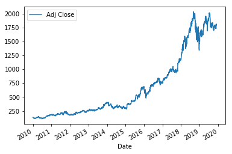

```python
# line graph
amazon_price.plot()
```

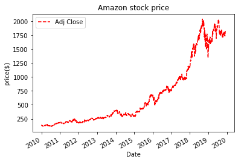

```python
amazon_price.plot(color='red',linestyle='dashed', ylabel='price($)', title='Amazon stock price')
```

**Parameters:** (Copied from this [blog](https://towardsdatascience.com/a-guide-to-pandas-and-matplotlib-for-data-exploration-56fad95f951c))

- kind — ‘bar’,‘barh’,‘pie’,‘scatter’,‘kde’ etc which can be found in the documentation.
- color — Which accepts and array of hex codes corresponding sequential to each data series / column.
- linestyle — ‘solid’, ‘dotted’, ‘dashed’ (applies to line graphs only)
- xlim, ylim — specify a tuple (lower limit, upper limit) for which the plot will be drawn
- legend— a boolean value to display or hide the legend
- labels — a list corresponding to the number of columns in the dataframe, a descriptive name can be provided here for the legend
- title — The string title of the plot

Pandas Plot Documentation can be found [here](https://pandas.pydata.org/pandas-docs/version/0.23.4/generated/pandas.DataFrame.plot.html).

**Popular Python visualization libraries:**

- [Matplotlib](https://matplotlib.org)
- [Seaborn](https://seaborn.pydata.org)
- [Plotly](https://dash-gallery.plotly.host/Portal/)

**🤓 Exercise 4: Visualize minimum variance frontier**

This code below randomly generate 10,000 portfolios constructed of the five stocks and calculate the risk and return of each portfolio. Note that this chunk of code is beyond the scope of this BootCamp, but feel free to dig into it if you are interested.

```python
import numpy as np
from random import uniform

# calculate the expected return and coviance of the five stocks
ret_mean = stock_returns.mean()
ret_cov = stock_returns.cov()

portfolio_list = []       # define an empty list

for i in range(10000):    # Generate one random portfolio in a loop. Iterate 10000 times.

    # generate a set of random weight on 5 portfolios which add up to be 1. Allow negative weight.
    w = [uniform(-1,2), uniform(-1,2), uniform(-1,2), uniform(-1,2)]
    weight = w + [1 - sum(w)]

    # calculate portfolio return and standard deviation
    port_ret = sum(weight*ret_mean)
    port_std = np.sqrt(np.dot(weight, np.dot(ret_cov, weight)))

    # add the portfolio to list
    portfolio_list.append([port_ret, port_std] +  weight)

# create a dataframe from the list
portfolio = pd.DataFrame(portfolio_list, columns=['return', 'std', 'weight_AAPL', 'weight_CVX',
                                                  'weight_SBUX','weight_NKE', 'weight_PFE'])
```

```python
portfolio
```

|  | return | std | weight_AAPL | weight_CVX | weight_SBUX | weight_NKE | weight_PFE |
| --- | --- | --- | --- | --- | --- | --- | --- |
| 0 | 0.009644 | 0.072848 | -0.117906 | 0.526019 | -0.454329 | 0.739894 | 0.306322 |
| 1 | 0.035160 | 0.117110 | 0.684293 | -0.728531 | -0.687031 | 1.323462 | 0.407808 |
| 2 | 0.002075 | 0.147053 | -0.371525 | 0.816467 | 1.997295 | -0.147564 | -1.294673 |
| 3 | 0.003999 | 0.086934 | -0.470299 | -0.491965 | 1.414554 | 0.089292 | 0.458418 |
| 4 | 0.058795 | 0.234264 | 1.482384 | -0.552026 | 0.749435 | 1.754362 | -2.434155 |
| ... | ... | ... | ... | ... | ... | ... | ... |
| 9995 | -0.002996 | 0.155640 | -0.386438 | 1.852224 | 0.899853 | -0.067823 | -1.297816 |
| 9996 | 0.031519 | 0.163782 | 1.063854 | 1.428790 | 0.382955 | 0.075292 | -1.950892 |
| 9997 | 0.025410 | 0.144039 | 1.059976 | 1.740886 | -0.575778 | -0.401531 | -0.823553 |
| 9998 | 0.055916 | 0.257195 | 1.538167 | 0.486144 | 0.682756 | 1.603535 | -3.310602 |
| 9999 | 0.057055 | 0.297293 | 1.751869 | 1.532894 | -0.056971 | 1.721180 | -3.948973 |

10000 rows × 7 columns

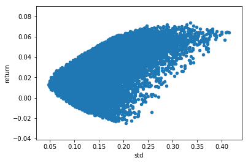

```python
# Plot the feasible set. The left boundary is the minumum variance frontier!
portfolio.plot.scatter('std', 'return')
```

You can also use Pandas to answer questions like:

**🧐 Which portfolio gives the lowest variance?**

```python
portfolio.nsmallest(1, 'std')
```

|  | return | std | weight_AAPL | weight_CVX | weight_SBUX | weight_NKE | weight_PFE |
| --- | --- | --- | --- | --- | --- | --- | --- |
| 7064 | 0.013208 | 0.047292 | 0.077235 | 0.197312 | 0.074003 | 0.292364 | 0.359086 |

**🧐 Which portfolio gives the largest sharpe ratio?**

```python
portfolio['sharpe_ratio'] = portfolio['return']/portfolio['std']
portfolio.nlargest(1, 'sharpe_ratio')
```

|  | return | std | weight_AAPL | weight_CVX | weight_SBUX | weight_NKE | weight_PFE | sharpe_ratio |
| --- | --- | --- | --- | --- | --- | --- | --- | --- |
| 2001 | 0.026573 | 0.063711 | 0.605818 | -0.161353 | 0.229121 | 0.267503 | 0.05891 | 0.417081 |

## 4. More resources for Python learning

**Recommend courses:**

- MFin 290 (winter): Programming & Data Analytics

**Online courses:**

- [Codecademy: Analyze finance data with Python](https://www.codecademy.com/learn/paths/finance-python) (highly recommended, but not free)
- [Coursera: Python and Statistics for Financial Analysis](https://www.coursera.org/learn/python-statistics-financial-analysis) (free)

**Other resources:**

- [Learn Python - Full course for beginners](https://www.youtube.com/watch?v=rfscVS0vtbw&feature=emb_title)
- [A Pandas Video tutorial series](https://www.youtube.com/playlist?list=PL5-da3qGB5ICCsgW1MxlZ0Hq8LL5U3u9y).
- A handy [Pandas cheatsheet](http://pandas.pydata.org/Pandas_Cheat_Sheet.pdf).
- Official documentations
- Online blogs

**Textbook:**

- [Python for Finance](https://www.amazon.com/Python-Finance-Mastering-Data-Driven/dp/1492024333)

**This is the end of our Python Bootcamp. Happy coding!👻**